# Acacia_saligna

Lilith Diener

2025-02-21

## Temporal assessment of the density and population structure of Acacia saligna in the Cape Flats Nature Reserve

Let us start with the coding… Firstly, we are installing and loading all necessary packages using the library() function.

```r
# Install and load packages
# install.packages("tidyr")
# options("install.lock"=FALSE)
# install.packages("ggplot2")
# options("install.lock"=FALSE)

library(tidyr)
library(dplyr)
library(ggplot2)
```

Now, we can proceed to read in the dataset using read.csv().

```r
AcaciaSaligna_Data <- read.csv("AcaciaSaligna_Data.csv")
```

I removed the columns “Area” and “Number_other_species” from the dataset as they are not needed for this analysis. Note that these two columns are marked as “NULL”.

```r
AcaciaSaligna_Data <- read.table("AcaciaSaligna_Data.csv", header = TRUE,
                                 sep = ",",
        colClasses = c("NULL","integer", "character", "integer", "integer",
                                       "numeric",
                                        "integer", "numeric", "integer", "numeric", "NULL"))
```

Here, I converted all the densities in the dataset to numeric values and verified the output using str().

```r
# Convert factor columns to numeric
AcaciaSaligna_Data <- AcaciaSaligna_Data %>%
  mutate(
    Total_Density = as.numeric(as.character(Total_Density)),
    Seedling_Density = as.numeric(as.character(Seedling_Density)),
    Adult_Density = as.numeric(as.character(Adult_Density))
  )

str(AcaciaSaligna_Data)
```

```
## 'data.frame':    84 obs. of  9 variables:
##  $ Year            : int  2019 2019 2019 2019 2019 2019 2019 2020 2020 2020 ...
##  $ Vegetation_Type : chr  "Strandveld" "Strandveld" "Strandveld" "Strandveld" ...
##  $ Quadrat         : int  1 2 3 4 5 6 7 1 2 3 ...
##  $ Total_Number    : int  33 22 17 26 41 15 4 25 3 7 ...
##  $ Total_Density   : num  2.1 1.4 1.1 1.6 2.6 0.9 0.3 1.6 0.2 0.4 ...
##  $ Seedling_Number : int  7 6 3 4 15 6 3 20 3 4 ...
##  $ Seedling_Density: num  0.4 0.4 0.2 0.3 0.9 0.4 0.2 1.3 0.2 0.3 ...
##  $ Adult_Number    : int  26 16 14 22 26 9 1 5 0 3 ...
##  $ Adult_Density   : num  1.6 1 0.9 1.4 1.6 0.6 0.1 0.3 0 0.2 ...
```

In the last few steps, I calculated the average total, adult, and seedling densities for each year and vegetation type. I also put the data into long format using pivot_longer().

```r
# Calculate average densities for each year
summary_data <- AcaciaSaligna_Data %>%
group_by(Year) %>%
summarise(Total_Density = mean(Total_Density, na.rm = TRUE),
Seedling_Density = mean(Seedling_Density, na.rm = TRUE),
Adult_Density = mean(Adult_Density, na.rm = TRUE))

str(AcaciaSaligna_Data) # Check structure of data
```

```
## 'data.frame':    84 obs. of  9 variables:
##  $ Year            : int  2019 2019 2019 2019 2019 2019 2019 2020 2020 2020 ...
##  $ Vegetation_Type : chr  "Strandveld" "Strandveld" "Strandveld" "Strandveld" ...
##  $ Quadrat         : int  1 2 3 4 5 6 7 1 2 3 ...
##  $ Total_Number    : int  33 22 17 26 41 15 4 25 3 7 ...
##  $ Total_Density   : num  2.1 1.4 1.1 1.6 2.6 0.9 0.3 1.6 0.2 0.4 ...
##  $ Seedling_Number : int  7 6 3 4 15 6 3 20 3 4 ...
##  $ Seedling_Density: num  0.4 0.4 0.2 0.3 0.9 0.4 0.2 1.3 0.2 0.3 ...
##  $ Adult_Number    : int  26 16 14 22 26 9 1 5 0 3 ...
##  $ Adult_Density   : num  1.6 1 0.9 1.4 1.6 0.6 0.1 0.3 0 0.2 ...
```

```r
# Calculate average densities for each year and vegetation type
summary_data <- AcaciaSaligna_Data %>%
  group_by(Year, Vegetation_Type) %>%
  summarise(
    Total_Density = mean(Total_Density, na.rm = TRUE),
    Seedling_Density = mean(Seedling_Density, na.rm = TRUE),
    Adult_Density = mean(Adult_Density, na.rm = TRUE),
    .groups = "drop"
  ) %>%
  pivot_longer(cols = c(Total_Density, Seedling_Density, Adult_Density),
               names_to = "Group",
               values_to = "Avg_Density")
```

Finally, I created three bar charts showing changes in the average total, seedling and adult density of A. saligna per square meter in each area from 2019 to 2024. Please note that the Ecotone and Sand Fynbos areas were only sampled in some of the years.

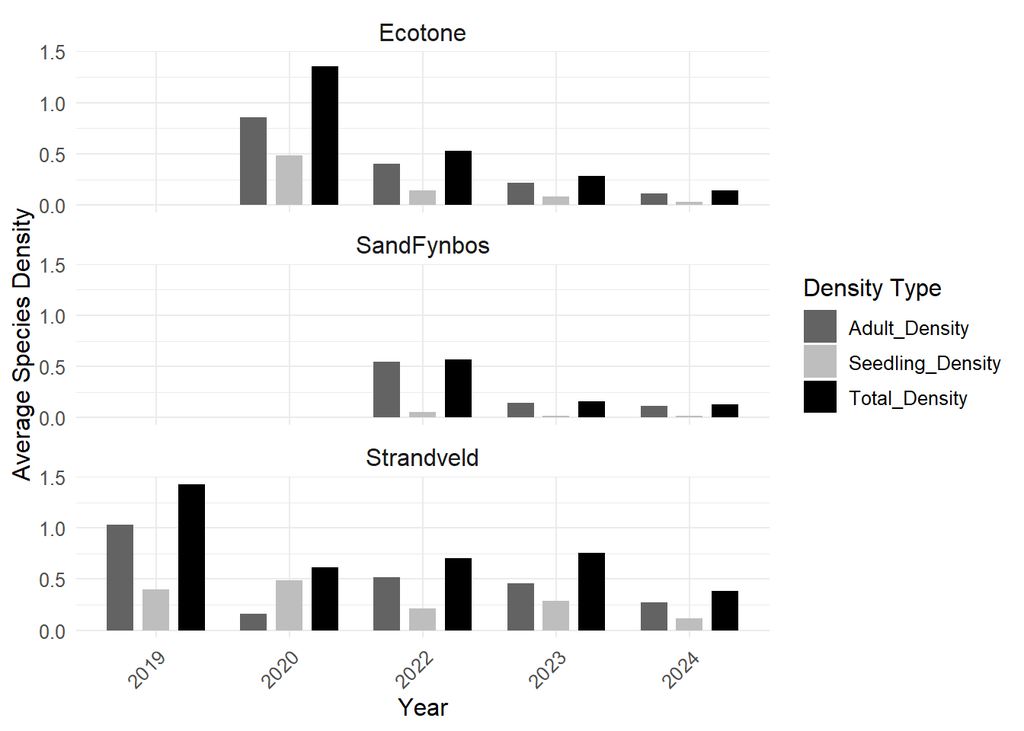

```r
# Plot bar charts
ggplot(summary_data, aes(x = factor(Year), y = Avg_Density, fill = Group)) +
  geom_bar(stat = "identity", position = position_dodge(width = 0.8), width = 0.6) +
  facet_wrap(~Vegetation_Type, ncol = 1) +
  labs(x = "Year", y = "Average Species Density", fill = "Density Type") +
  theme_minimal() +
  scale_fill_manual(values = c("Total_Density" = "black",
                               "Seedling_Density" = "grey",
                               "Adult_Density" = "grey39")) +
  theme(text = element_text(size = 12),
        strip.text = element_text(size = 12),
        axis.text.x = element_text(angle = 45, hjust = 1))
```

Figure 1: Bar graphs showing changes in the average total, seedling and adult density of A. saligna per square meter in the three areas from 2019 to 2024.